# Step 2 Geographic Data Processing

Natasha Hardy

17/03/2022

## About

This document appends longhurst province code and information to our study location and covariate information, from the global albacore diet data project.

## Workspace

```r
#Spatial & plot
library(sf)
library(rnaturalearth)
library(ggplot2)
library(sp)
#Data
library(here)
"%notin%" = Negate('%in%')
here::here()
```

```
## [1] "/Users/tashhardy/Documents/GitHub/albacore-diet-global"
```

```r
library(dplyr)
```

## Setting up the map

### Base map

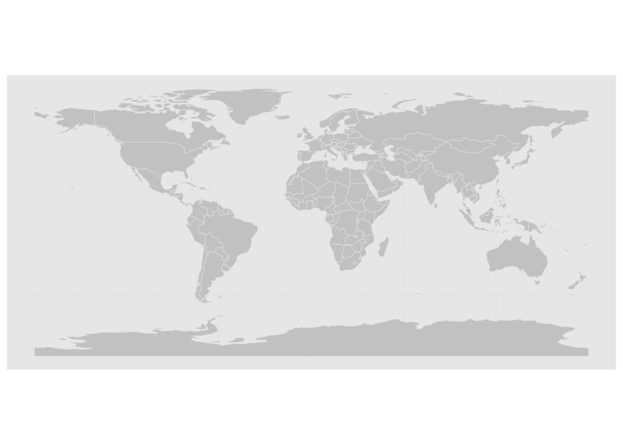

```r
# Base map
world_map <- rnaturalearth::ne_countries(scale = "small", returnclass = c("sf"))
baseMap <- ggplot() + geom_sf(data = world_map, size = 0.2, fill = "gray80", col = "gray90") +
    theme(panel.grid.major = element_line(color = gray(0.9), linetype = "dashed",
        size = 0.5))
baseMap
```

### Add Longhurst Province Shapefile

```r
# Load the Longhurst shapefile, convert to SpatialPolygonsDataFrame
longhurst <- st_read(here::here("code/longhurst/Longhurst_world_v4_2010.shp"))
names(longhurst)
```

```
## [1] "ProvCode"  "ProvDescr" "geometry"
```

```r
head(longhurst)
```

```
## Simple feature collection with 6 features and 2 fields
## Geometry type: MULTIPOLYGON
## Dimension:     XY
## Bounding box:  xmin: -180 ymin: 25.5 xmax: 180 ymax: 90
## Geodetic CRS:  WGS 84
##   ProvCode                                                         ProvDescr
## 1     BPLR                              Polar - Boreal Polar Province (POLR)
## 2     ARCT                                  Polar - Atlantic Arctic Province
## 3     SARC                               Polar - Atlantic Subarctic Province
## 4     NADR                    Westerlies - N. Atlantic Drift Province (WWDR)
## 5     GFST                                 Westerlies - Gulf Stream Province
## 6     NASW Westerlies - N. Atlantic Subtropical Gyral Province (West) (STGW)
##                         geometry
## 1 MULTIPOLYGON (((-161.1843 6...
## 2 MULTIPOLYGON (((-21.51305 6...
## 3 MULTIPOLYGON (((11.26472 63...
## 4 MULTIPOLYGON (((-11.5 57.5,...
## 5 MULTIPOLYGON (((-43.5 43.5,...
## 6 MULTIPOLYGON (((-39.5 25.5,...
```

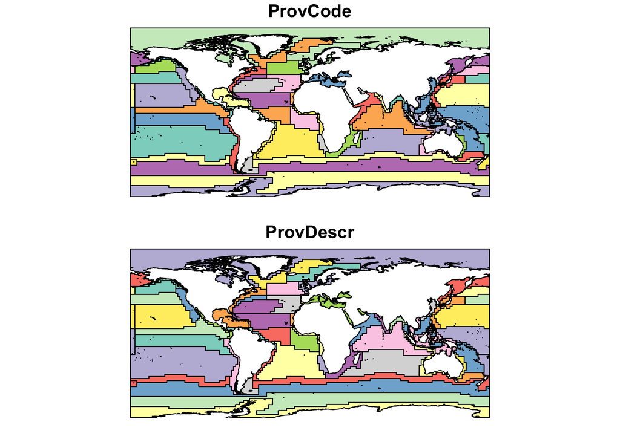

```r
#Check data
plot(longhurst)
```

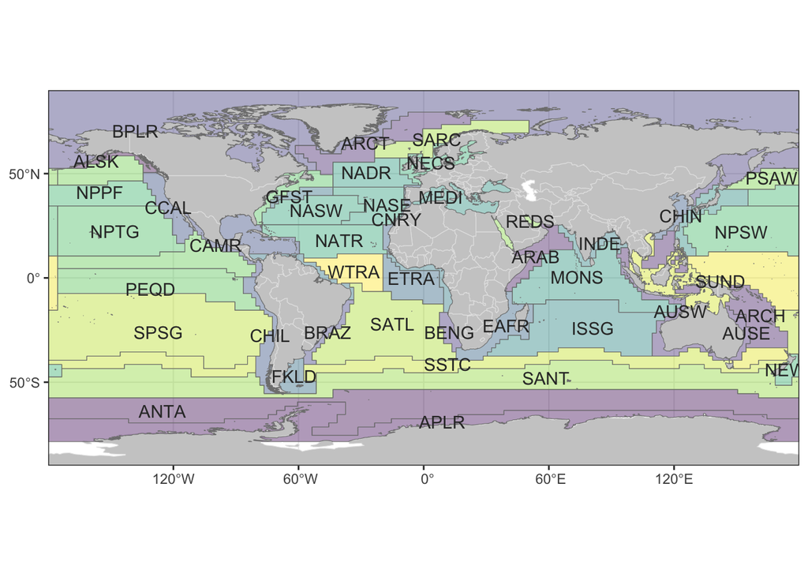

```r
# Plot provinces should work as before, just with annoying warning messages
sf_use_s2(FALSE)
longMap <- baseMap + geom_sf(data = longhurst, aes(fill = ProvCode), size = .2, col = "grey50", alpha=.4)+
  theme_bw() + theme(legend.position="none", axis.title = element_blank()) +
  geom_sf_text(data = longhurst %>%
                 dplyr::group_by(ProvCode) %>%
                 dplyr::summarize(n()),
               aes(label = ProvCode),
               colour = "grey20", check_overlap = TRUE) +
  scale_fill_viridis_d()+ coord_sf(expand = FALSE)
longMap
```

### Manipulate Longhurst shp to spatial polygon df

```r
longs <- sf:::as_Spatial(longhurst) # SpatialPolygonsDataFrame

st_crs(longs)
```

```
## Coordinate Reference System:
##   User input: WGS 84
##   wkt:
## GEOGCRS["WGS 84",
##     DATUM["World Geodetic System 1984",
##         ELLIPSOID["WGS 84",6378137,298.257223563,
##             LENGTHUNIT["metre",1]]],
##     PRIMEM["Greenwich",0,
##         ANGLEUNIT["degree",0.0174532925199433]],
##     CS[ellipsoidal,2],
##         AXIS["geodetic latitude (Lat)",north,
##             ORDER[1],
##             ANGLEUNIT["degree",0.0174532925199433]],
##         AXIS["geodetic longitude (Lon)",east,
##             ORDER[2],
##             ANGLEUNIT["degree",0.0174532925199433]],
##     ID["EPSG",4326]]
```

### Albacore data

```r
alb <- read.csv(here::here("data/2_output_data/alb_covars.csv"), head = TRUE, sep= ",")
rep_ID = alb$rep_ID
# Set coordinates
coordinates(alb) <- ~ LocatLongitude + LocatLatitude # SpatialPointsDataFrame
# Set the projection of the SpatialPointsDataFrames to match the projection of the shapefile
suppressWarnings(proj4string(alb) <- proj4string(longs))

# Extract the Longhurst province of each location
provinces <- over(alb, longs)
alb$province <- provinces$ProvDescr
alb$code <- provinces$ProvCode
provinces$rep_ID = rep_ID

write.csv(alb, here::here("data/2_output_data/alb_covars_longhurst.csv"), row.names = FALSE)
```

### Albacore data map

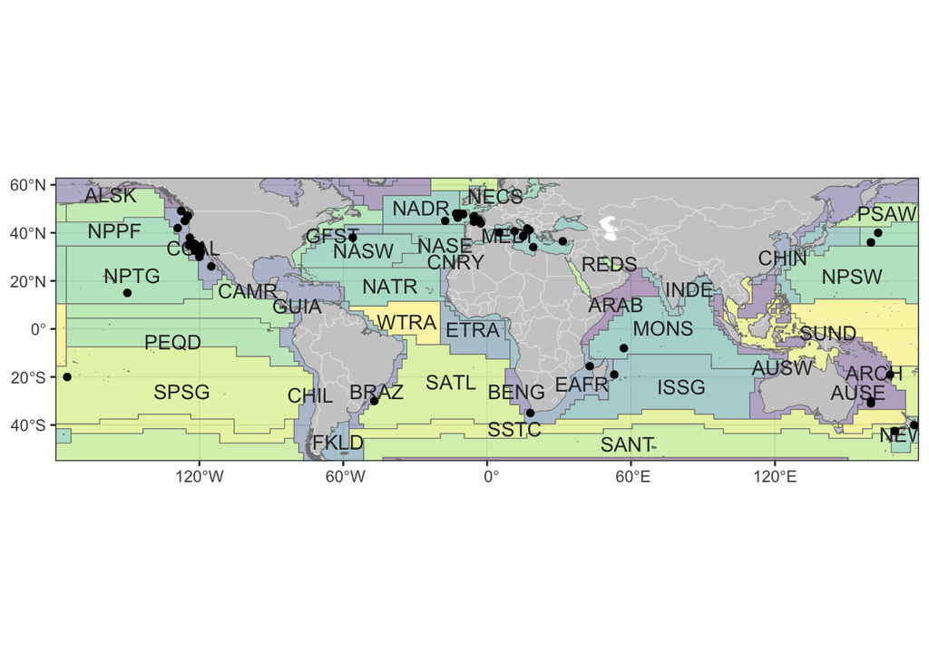

```r
# Map
albMap <- longMap + geom_point(data = as.data.frame(alb), aes(x = LocatLongitude,
    y = LocatLatitude)) + ylim(c(-55, 63))
albMap
```

```r
ggsave(here::here("outputs_figures/1_maps/alb_global_map_f.pdf"), plot = albMap,
    dpi = 300)
ggsave(here::here("outputs_figures/1_maps/alb_global_map_f.jpeg"), plot = albMap,
    dpi = 300)
```

```
## Warning in st_point_on_surface.sfc(sf::st_zm(x)): st_point_on_surface may not
## give correct results for longitude/latitude data
```

```
## Warning: Removed 5 rows containing missing values (`geom_text()`).
```

## Old Code

### Note re troubles with sf package especially and comms with Barb

Re - warning messages and errors after loading the longhurst shapefile doc.

From Barb:

It’s an issue with the update of sf (see here). You can use the fix they suggest, i.e. add “sf::sf_use_s2(FALSE)” before line 35. That works for me.

You can just add “ylim(c(-52, 52)” or something similar to trim the map extent, in the plotting code. I would add “theme_bw()” just before “theme(legend.position …”, as that will keep a border around the whole map area.

The warnings are annoying but they appear harmless. It’s not uncommon for R to not like some features in imported shapefiles. The bounding box errors relate to province BPLR in the Arctic (if you subset out that row, you’ll notice these warnings disappear). The other errors are mostly related to the fact that we’re doing spatial things with unprojected polygons. That would be an issue if, say, we wanted to calculate the area of each polygon, which requires us to project the dataset into a coordinate reference system that uses meters rather than decimal degrees. But as we’re just simplifying the shapefile and mapping it, I don’t think it matters.